# Term Project Example Code and Workflow

Author

ENVH 556 Autumn 2024 Instructors

This document was rendered on October 03, 2024.

# Objectives

The objective of this script is to provide you with an example workflow and code to complete the analytic section of the Term Project described in **Project Steps**.

This document does not include all aspects required for the project (e.g., write up, group work). Please review that documentation.

# Example Research Questions

# Explore and Describe the Data

## Numbers and Tables

Let’s start by describing the data. What pollutants are included? How many observations are there?

```r
# total rows and columns
dim(no2)
```

```
[1] 309   5
```

```r
# number of readings for each variable
table(no2$variable)
```

```
no2
309
```

Generate a summary table describing the distribution of pollutant concentrations (Min, Q25, median, mean, Q75, Max). Here’s an example.

```r
no2 %>%
  #here, we are only looking at NO2. In many other analyses, you may want to look and group by multiple variables
  group_by(variable) %>%
  dplyr::summarize(
    N = n(),
    Min = min(value),
    Q25 = quantile(value, 0.25),
    Median = median(value),
    Q75 = quantile(value, 0.75),
    Max = max(value),
    Mean = mean(value),
    SD = sd(value)
    ) %>%
  kable(caption = "Distribution of annual average pollutant concentrations",
        digits = 1,
        # add a comma as the thousands separator
        format.args = list(big.mark=",")) %>%
  kable_styling()
```

Distribution of annual average pollutant concentrations

| variable | N | Min | Q25 | Median | Q75 | Max | Mean | SD |
| --- | --- | --- | --- | --- | --- | --- | --- | --- |
| no2 | 309 | 3.9 | 7.5 | 8.8 | 10.4 | 22.5 | 9.2 | 2.6 |

## Visualizations

Visualize the distribution of pollutant concentrations. Below is a density plot that shows how these measurements are distributed.

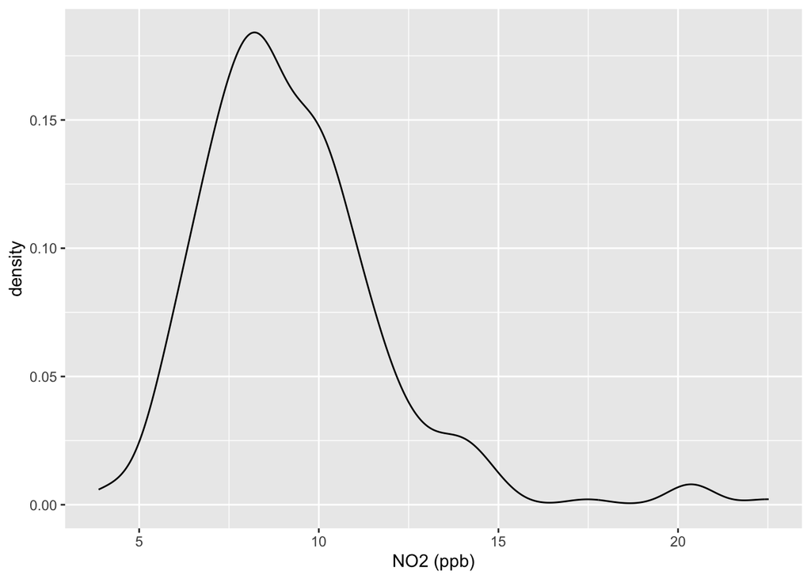

```r
no2 %>%
  ggplot(aes(x=value)) +
  geom_density() +
  labs(x= "NO2 (ppb)")
```

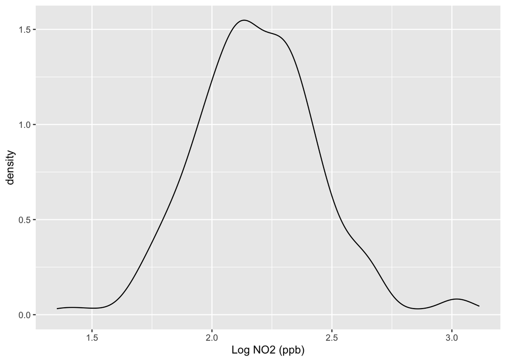

```r
# same as above but with log(NO2)
no2 %>%
  ggplot(aes(x=log(value))) +
  geom_density() +
  labs(x= "Log NO2 (ppb)")
```

Mapping environmental data can help us detect spatial patterns that may otherwise be missed.

What do you see? Where are the highest and lowest concentrations? Is this what you expected to see?

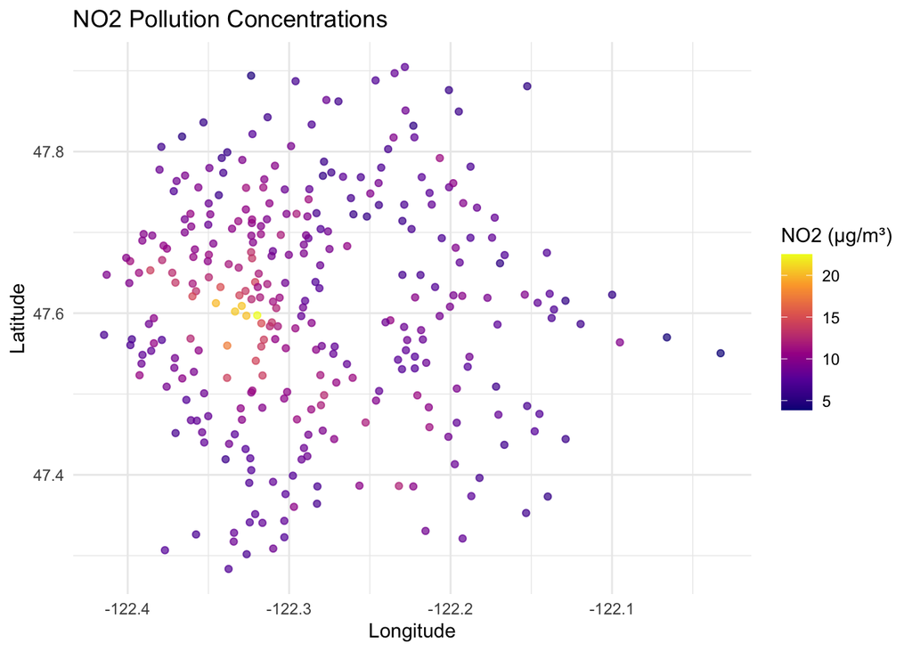

```r
# quick plot the data without a basemap.
# note that the lat/long may be distorted here
ggplot(data = no2, aes(x = longitude, y = latitude)) +
  geom_point(aes(color = value), alpha = 0.7) +
  scale_color_viridis_c(option = "C", name = "NO2 (µg/m³)") +
  labs(title = "NO2 Pollution Concentrations",
       x = "Longitude",
       y = "Latitude") +
  theme_minimal() +
  theme(legend.position = "right")
```

```r
# optional - add a basemap and make the plot interactive
leaflet(data = no2) %>%
  addTiles() %>%  # Add default OpenStreetMap tiles
  addCircleMarkers(
    lng = ~longitude,
    lat = ~latitude,
    # Adjust radius size based on value (use sqrt for better scaling)
    radius=3,
    color = ~colorNumeric("viridis", domain = no2$value, reverse = T)(value),
    fillOpacity = 0.7,
    # Add a popup with details
    popup = ~paste("Location:", location,
                   "<br>", # Line break
                   "NO2 (ppb):", round(value, 1))
  ) %>%
  addLegend(
    pal = colorNumeric("viridis", domain = no2$value,  reverse = T),
    values = ~value,
    title = "NO2 (ppb)",
    opacity = 0.7,
    position = "bottomright"
  )
```

[interactive chart not shown]

## Check the linearity assumption

Compare NO2 levels to land use variables (covariates) that might be important predictors. Here, we’ll only look one predictor (m_to_a1 - highways) as an example. Your project should consider other variables and expand on this.

How should the data be modeled based on these relationships? On the native scale? Log scale? Something else?

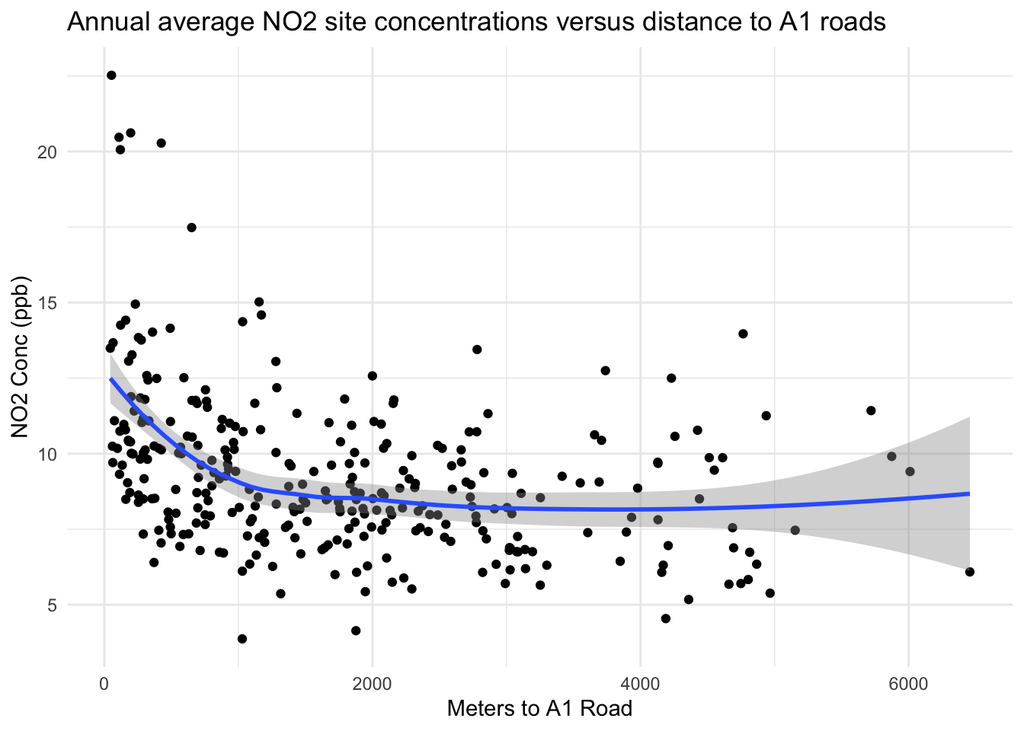

```r
# combine NO2 concentrations with geocovariates at those locations
no2_covariates <- left_join(no2, mm_covariates, by = join_by(location, longitude, latitude))

no2_covariates %>%
  ggplot(aes(x=m_to_a1, y=value)) +
  geom_point() +
  geom_smooth(method="loess") +
  theme_minimal() +
  labs(x = "Meters to A1 Road",
       y = "NO2 Conc (ppb)",
       title = "Annual average NO2 site concentrations versus distance to A1 roads"
       )
```

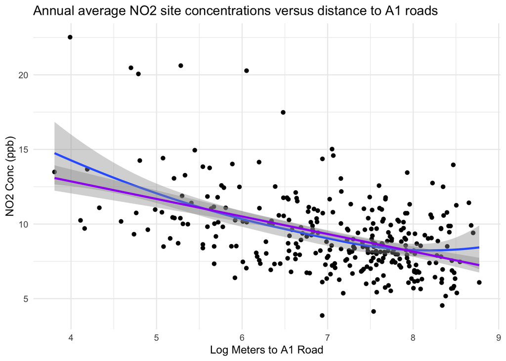

```r
# same as above using log m_to_a1 - looks more linear!
# try other transformations (see examples below)
left_join(no2, mm_covariates, by = "location") %>%
  ggplot(aes(#x=m_to_a1,
             x=log(m_to_a1),
             #y=log(value),
             y=value
             )) +
  geom_point() +
  # smooth line to characterize the data
  geom_smooth(method="loess") +
  # check that loess is more/less linear (do these largely overlap?)
  geom_smooth(method = "lm", col="purple") +
  theme_minimal() +
  labs(x = "Log Meters to A1 Road",
       y = "NO2 Conc (ppb)",
       title = "Annual average NO2 site concentrations versus distance to A1 roads"
       )
```

# Analyses to Support Your Research Question

## Example of Exposure Prediction Model

We’ll look at m_to_a1 again as a simple example.

```r
lm1 <- lm(value ~ log(m_to_a1), data=no2_covariates)

summary(lm1)
```

```
Call:
lm(formula = value ~ log(m_to_a1), data = no2_covariates)

Residuals:
    Min      1Q  Median      3Q     Max
-5.5343 -1.4496 -0.3466  1.2184  9.8336

Coefficients:
             Estimate Std. Error t value Pr(>|t|)
(Intercept)   17.5605     0.8974  19.568   <2e-16 ***
log(m_to_a1)  -1.1757     0.1255  -9.369   <2e-16 ***
---
Signif. codes:  0 '***' 0.001 '**' 0.01 '*' 0.05 '.' 0.1 ' ' 1

Residual standard error: 2.317 on 307 degrees of freedom
Multiple R-squared:  0.2223,    Adjusted R-squared:  0.2198
F-statistic: 87.78 on 1 and 307 DF,  p-value: < 2.2e-16
```

## Example of Results Evaluation (Out-of-Sample Model Performance)

Calculate the $R^2_{CV}$ to evaluate how well the model predicts.

Note that here, we develop a model using a subset of the data, and predict at a *different* subset of the data the model has never seen to get a better idea of how well the model might perform out-of-sample. There are many ways to approach this. This is one common approach.

```r
# function to conduct cross-validation
cv_lm <- function(data,
                  f = 10, # ten folds default
                  model_formula = "value ~ log(m_to_a1)" # input your lm() here
                  ) {

  # Convert the input model formula from string to formula
  model_formula <- as.formula(model_formula)

  # Randomly assign each row to a fold
  set.seed(123)  # Set seed for reproducibility
  data <- data %>%
    mutate(fold = sample(1:f, size = nrow(data), replace = TRUE))

  # Initialize an empty data frame to store predictions
  predictions <- data.frame()

  # Perform f-fold cross-validation
  for (i in 1:f) {
    # Split into training and test sets
    train_data <- data %>% filter(fold != i)
    test_data <- data %>% filter(fold == i)

    # Fit the model to the training data using the input model formula
    lm1 <- lm(model_formula, data = train_data)

    # Make predictions on the test data
    test_data$predicted_value <- predict(lm1, newdata = test_data)

    # Store the predictions
    predictions <- rbind(predictions, test_data)
  }

  return(predictions)
}
```

```r
no2_covariates <- cv_lm(data = no2_covariates,
                        f = 10, # ten folds default
                        model_formula = "value ~ log(m_to_a1)")
```

Calculate CV MSE-based R2 ($R^2_{CV MSE}$).

```r
calculate_mse_r2 <- function(observed, predicted) {
  # Calculate MSE
  mse <- mean((observed - predicted)^2)

  # Calculate the variance of the observed values
  ## NOTE: var() calculates the sample variance, which divides by n-1 (vs n).
  ## An alternative is to, use: mean((observed - mean(observed))^2), which estimates a population-level variance that may be biased
  variance <- var(observed)

  # Calculate MSE-based R²
  mse_r2 <- 1 - (mse / variance)

  return(mse_r2)
}
```

```r
calculate_mse_r2(observed = no2_covariates$value,
                 predicted = no2_covariates$predicted_value)
```

```
[1] 0.212509
```

Calculate regression-based R2 ($R^2_{CV Reg}$).

How does this differ from $R^2_{CV MSE}$? Which will you report? Why?

```r
calculate_regression_r2 <- function(observed, predicted) {
  # Fit a linear model of predicted values on observed values
  reg_model <- lm(predicted ~ observed)

  # Extract the R² value
  regression_r2 <- summary(reg_model)$r.squared

  return(regression_r2)
}
```

```r
calculate_regression_r2(observed = no2_covariates$value,
                 predicted = no2_covariates$predicted_value)
```

```
[1] 0.210159
```

Calculate $RMSE$.

What different information does this provide when compared to $R^2_{CV}$?

```r
calculate_rmse <- function(observed, predicted) {
  # Calculate RMSE
  rmse <- sqrt(mean((observed - predicted)^2))

  return(rmse)
}
```

```r
calculate_rmse(observed = no2_covariates$value,
                 predicted = no2_covariates$predicted_value)
```

```
[1] 2.328277
```

## Calcualte and Visualize the Residuals

```r
no2_covariates <- no2_covariates %>%
  mutate(prediction_residual = predicted_value - value)
```

What is the distribution of the modeling errors? Is this meaningful compared to the observed concentrations?

```r
summary(no2_covariates$prediction_residual)
```

```
     Min.   1st Qu.    Median      Mean   3rd Qu.      Max.
-9.889779 -1.191218  0.354779 -0.006254  1.466729  5.554826
```

Plot predicted values against the residuals (prediction errors). Is there any pattern?

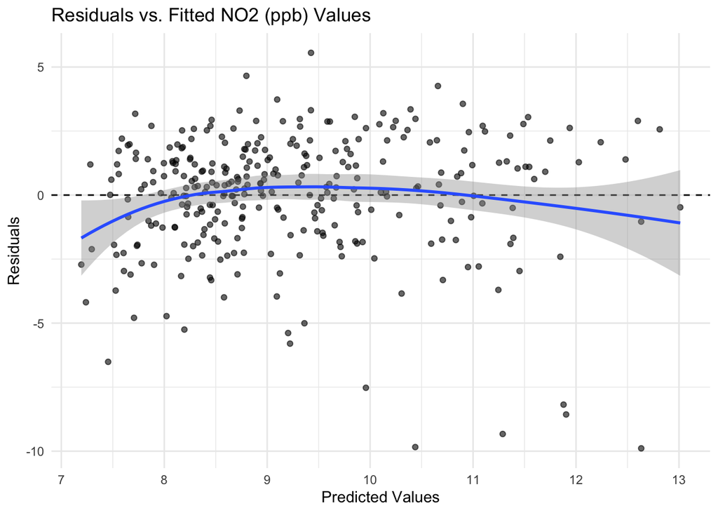

```r
ggplot(no2_covariates, aes(x = predicted_value, y = prediction_residual)) +
  geom_point(alpha = 0.6) +
  geom_hline(yintercept = 0, linetype = "dashed") +
  geom_smooth(method="loess") +
  labs(title = "Residuals vs. Fitted NO2 (ppb) Values",
       x = "Predicted Values",
       y = "Residuals") +
  theme_minimal()
```

```r
# # QQ plot
# ggplot(no2_covariates, aes(sample = prediction_residual)) +
#   stat_qq() +
#   stat_qq_line() +
#   labs(title = "Normal Q-Q Plot of Residuals",
#        x = "Theoretical Quantiles",
#        y = "Sample Quantiles") +
#   theme_minimal()
```

Here’s a historgram of the residuals. The histogram should resemble a bell-shaped curve if the residuals are approximately normally distributed.

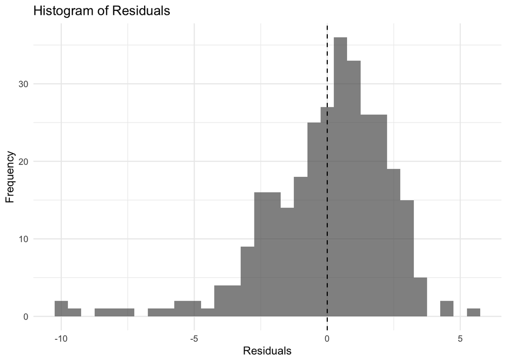

```r
ggplot(no2_covariates, aes(x = prediction_residual)) +
  geom_histogram(binwidth = 0.5, alpha = 0.7) +
  geom_vline(xintercept = 0, linetype="dashed") +
  labs(title = "Histogram of Residuals",
       x = "Residuals",
       y = "Frequency") +
  theme_minimal()
```

```r
# # Checks the homoscedasticity (constant variance) assumption. You plot the square root of the absolute residuals against the fitted values.
#
#
# ggplot(no2_covariates, aes(x = predicted_value, y = sqrt(abs(prediction_residual)))) +
#   geom_point(alpha = 0.6) +
#   geom_smooth(method = "loess") +
#   labs(title = "Scale-Location Plot",
#        x = "Predicted Values",
#        y = "√|Residuals|") +
#   theme_minimal()
```

```r
# #Residuals vs. Each Covariate: You can create scatter plots of residuals against each covariate in your model to check for any patterns that might suggest non-linearity or missing predictors.
#
# ggplot(no2_covariates, aes(x = log(m_to_a1), y = prediction_residual)) +
#   geom_point(alpha = 0.6) +
#   geom_hline(yintercept = 0, linetype = "dashed") +
#   labs(title = "Residuals vs. log(m_to_a1)",
#        x = "log(m_to_a1)",
#        y = "Residuals") +
#   theme_minimal()
```

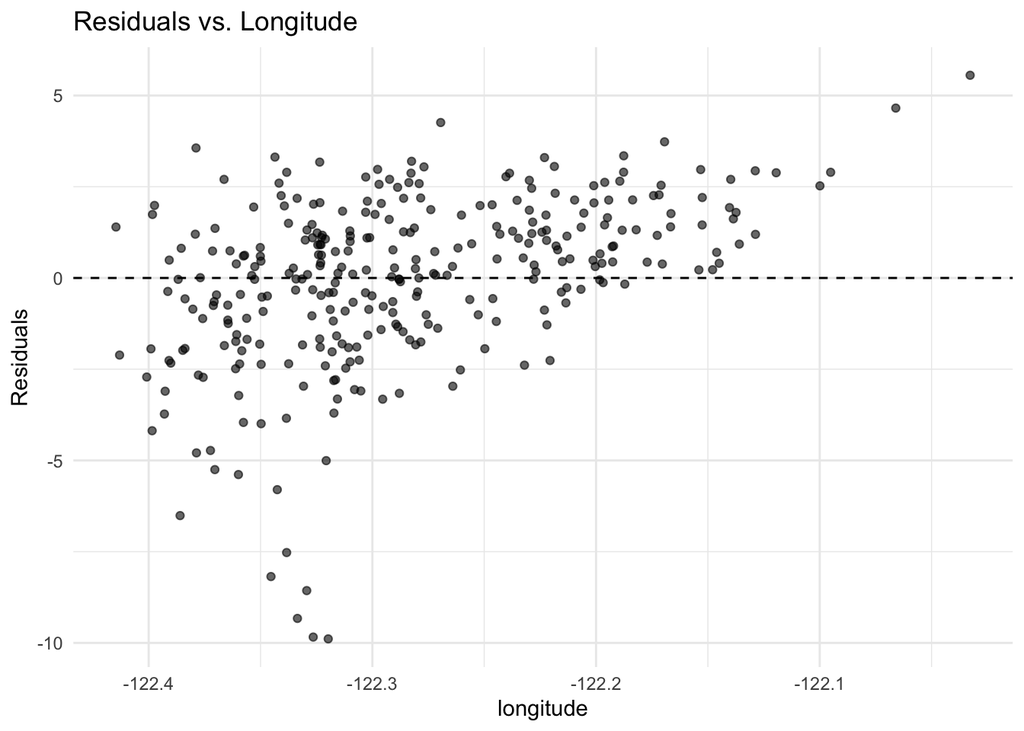

```r
# If data are spatially structured, a plot of residuals against a spatial index can help identify this. For example, you might plot residuals by latitude or longitude:

ggplot(no2_covariates, aes(x = longitude, y = prediction_residual)) +
  geom_point(alpha = 0.6) +
  geom_hline(yintercept = 0, linetype = "dashed") +
  labs(title = "Residuals vs. Longitude",
       #x = "Longitude",
       y = "Residuals") +
  theme_minimal()
```

Map the residuals - where are prediction errors the largest? Smallest?

```r
leaflet(data = no2_covariates) %>%
  addTiles() %>%  # Add default OpenStreetMap tiles
  addCircleMarkers(
    lng = ~longitude,
    lat = ~latitude,
    radius=3,
    color = ~colorNumeric("viridis", domain = no2_covariates$prediction_residual, reverse = T)(prediction_residual),
    fillOpacity = 0.7,
    popup = ~paste("Location:", location,
                   "<br>", # Line break
                   "NO2 (ppb) Residual:", round(prediction_residual, 1))
  ) %>%
  addLegend(
    pal = colorNumeric("viridis", domain = no2_covariates$prediction_residual,  reverse = T),
    values = ~prediction_residual,
    title = "NO2 (ppb)\nResidual",
    opacity = 0.7,
    position = "bottomright"
  )
```

[interactive chart not shown]

# Example of Application and Visualization of Findings (Predict Exposures at New Unmeasured Locations)

In this example, we’ll predict at grid locations in the Seattle area.

Remember, this assumes that our modeling data are representative of new prediction locations and the exposures of interest. How can you verify that? Here are some examples:

- Are these in the same area?
  - Yes - they are both in Seattle.
- Do the modeling covariates and new prediction location covarites overlap? You want to avoid clear covaraite extrapollation.
  - Let’s check below.

```r
summary(grid_covariates$m_to_a1)
```

```
   Min. 1st Qu.  Median    Mean 3rd Qu.    Max.
      0    1715    4254    5923    8724   25000
```

```r
head(sort(grid_covariates$m_to_a1))
```

```
[1] 0 1 1 1 2 3
```

If you have transformed any of your modeling variables, verify that the new dataset has the same transformations. Here, we’ll make sure any 0 values are converted to a small constant so that we can log-transform them without error.

```r
grid_covariates <- grid_covariates %>%
  # if a location is on an a1 (m_to_a1 is 0), make this a small constant (you cannot take the log of 0)
  mutate(m_to_a1 = ifelse(m_to_a1 ==0, 0.1, m_to_a1)) %>%
  # works better when predict() is in a different mutate()
  mutate(predicted_value = predict(lm1, newdata = .))

# # QC: check predictions
# grid_covariates %>% select(location_id, m_to_a1, predicted_value) %>% arrange(predicted_value) %>% View()

# summarize the predictions distribution
summary(grid_covariates$predicted_value)
```

```
   Min. 1st Qu.  Median    Mean 3rd Qu.    Max.
  5.654   6.892   7.737   8.013   8.805  20.268
```

## Map These Predictions

Where are the highest and lowest predicted areas of air pollution? Is this what you expected

What do we learn from these maps that we did not before?

```r
leaflet(data = grid_covariates) %>%
  addTiles() %>%
  addCircleMarkers(
    lng = ~longitude,
    lat = ~latitude,
    radius=3,
    color = ~colorNumeric("viridis", domain = grid_covariates$predicted_value, reverse = T)(predicted_value),
    fillOpacity = 0.7,
    popup = ~paste("location_id:", location_id,
                   "<br>", # Line break
                   "NO2 (ppb) Prediction:", round(predicted_value, 1))
  ) %>%
  addLegend(
    pal = colorNumeric("viridis", domain = grid_covariates$predicted_value,  reverse = T),
    values = ~predicted_value,
    title = "NO2 (ppb) Prediction",
    opacity = 0.7,
    position = "bottomright"
  )
```

[interactive chart not shown]

# Appendix

## Embedded code

```r
#-----setup-----

# clear work space of all objects and unload all extra (non-base) packages
rm(list = ls(all = TRUE))
if (!is.null(sessionInfo()$otherPkgs)) {
    res <- suppressWarnings(
            lapply(paste('package:', names(sessionInfo()$otherPkgs), sep=""),
                   detach, character.only=TRUE, unload=TRUE, force=TRUE))
    rm(res)
}

# Load pacman into memory, installing as needed
my_repo <- 'http://cran.r-project.org'
if (!require("pacman")) {install.packages("pacman", repos = my_repo)}

# Load the other packages, installing as needed.
pacman::p_load(knitr, tidyr, dplyr, forcats, stringr, purrr, ggplot2, Hmisc,
               kableExtra, # table formatting
               sf, #spatial analyses
               leaflet #optional: make a map
               )

# load functions we'll use throughout the course
source("global_functions.R")

#-----directory organization and read data-----

# where data is/will be stored
data_path <- c(file.path("Datasets", "mobile monitoring"))

# create directories if they do not already exist
if(!dir.exists(data_path)){dir.create(data_path, showWarnings=FALSE, recursive = TRUE)}

# read in files
## annual average air pollution concentrations from mobile monitoring
annual <- download_and_read_file(data_url = "https://zenodo.org/record/13761282/files/annual_data_and_predictions.csv?download=1",
                                 output_file_path = file.path(data_path, "annual_data_and_predictions.csv"))

# we'll only look at NO2 in this example
no2 <- annual %>%
  filter(variable=="no2") %>%
  # only keep the variables we'll use
  select(location, longitude, latitude, variable, value)

mm_covariates <- download_and_read_file(data_url = "https://zenodo.org/records/13761282/files/dr0311_mobile_covariates.csv?download=1",
                                 output_file_path = file.path(data_path, "dr0311_mobile_covariates.csv")) %>%
  # rename this to match 'annual'
  rename(location = native_id)


# covariates for a grid of locations (for prediction)
grid_covariates <- download_and_read_file(data_url = "https://zenodo.org/records/13761282/files/dr0311_grid_covariates.csv?download=1",
                                 output_file_path = file.path(data_path, "dr0311_grid_covariates.csv"))


# total rows and columns
dim(no2)

# number of readings for each variable
table(no2$variable)



no2 %>%
  #here, we are only looking at NO2. In many other analyses, you may want to look and group by multiple variables
  group_by(variable) %>%
  dplyr::summarize(
    N = n(),
    Min = min(value),
    Q25 = quantile(value, 0.25),
    Median = median(value),
    Q75 = quantile(value, 0.75),
    Max = max(value),
    Mean = mean(value),
    SD = sd(value)
    ) %>%
  kable(caption = "Distribution of annual average pollutant concentrations",
        digits = 1,
        # add a comma as the thousands separator
        format.args = list(big.mark=",")) %>%
  kable_styling()

no2 %>%
  ggplot(aes(x=value)) +
  geom_density() +
  labs(x= "NO2 (ppb)")

# same as above but with log(NO2)
no2 %>%
  ggplot(aes(x=log(value))) +
  geom_density() +
  labs(x= "Log NO2 (ppb)")

# quick plot the data without a basemap.
# note that the lat/long may be distorted here
ggplot(data = no2, aes(x = longitude, y = latitude)) +
  geom_point(aes(color = value), alpha = 0.7) +
  scale_color_viridis_c(option = "C", name = "NO2 (µg/m³)") +
  labs(title = "NO2 Pollution Concentrations",
       x = "Longitude",
       y = "Latitude") +
  theme_minimal() +
  theme(legend.position = "right")


# optional - add a basemap and make the plot interactive
leaflet(data = no2) %>%
  addTiles() %>%  # Add default OpenStreetMap tiles
  addCircleMarkers(
    lng = ~longitude,
    lat = ~latitude,
    # Adjust radius size based on value (use sqrt for better scaling)
    radius=3,
    color = ~colorNumeric("viridis", domain = no2$value, reverse = T)(value),
    fillOpacity = 0.7,
    # Add a popup with details
    popup = ~paste("Location:", location,
                   "<br>", # Line break
                   "NO2 (ppb):", round(value, 1))
  ) %>%
  addLegend(
    pal = colorNumeric("viridis", domain = no2$value,  reverse = T),
    values = ~value,
    title = "NO2 (ppb)",
    opacity = 0.7,
    position = "bottomright"
  )

# combine NO2 concentrations with geocovariates at those locations
no2_covariates <- left_join(no2, mm_covariates, by = join_by(location, longitude, latitude))

no2_covariates %>%
  ggplot(aes(x=m_to_a1, y=value)) +
  geom_point() +
  geom_smooth(method="loess") +
  theme_minimal() +
  labs(x = "Meters to A1 Road",
       y = "NO2 Conc (ppb)",
       title = "Annual average NO2 site concentrations versus distance to A1 roads"
       )

# same as above using log m_to_a1 - looks more linear!
# try other transformations (see examples below)
left_join(no2, mm_covariates, by = "location") %>%
  ggplot(aes(#x=m_to_a1,
             x=log(m_to_a1),
             #y=log(value),
             y=value
             )) +
  geom_point() +
  # smooth line to characterize the data
  geom_smooth(method="loess") +
  # check that loess is more/less linear (do these largely overlap?)
  geom_smooth(method = "lm", col="purple") +
  theme_minimal() +
  labs(x = "Log Meters to A1 Road",
       y = "NO2 Conc (ppb)",
       title = "Annual average NO2 site concentrations versus distance to A1 roads"
       )



lm1 <- lm(value ~ log(m_to_a1), data=no2_covariates)

summary(lm1)

# function to conduct cross-validation
cv_lm <- function(data,
                  f = 10, # ten folds default
                  model_formula = "value ~ log(m_to_a1)" # input your lm() here
                  ) {

  # Convert the input model formula from string to formula
  model_formula <- as.formula(model_formula)

  # Randomly assign each row to a fold
  set.seed(123)  # Set seed for reproducibility
  data <- data %>%
    mutate(fold = sample(1:f, size = nrow(data), replace = TRUE))

  # Initialize an empty data frame to store predictions
  predictions <- data.frame()
```

```r
  # Perform f-fold cross-validation
  for (i in 1:f) {
    # Split into training and test sets
    train_data <- data %>% filter(fold != i)
    test_data <- data %>% filter(fold == i)

    # Fit the model to the training data using the input model formula
    lm1 <- lm(model_formula, data = train_data)

    # Make predictions on the test data
    test_data$predicted_value <- predict(lm1, newdata = test_data)

    # Store the predictions
    predictions <- rbind(predictions, test_data)
  }

  return(predictions)
}

no2_covariates <- cv_lm(data = no2_covariates,
                        f = 10, # ten folds default
                        model_formula = "value ~ log(m_to_a1)")

calculate_mse_r2 <- function(observed, predicted) {
  # Calculate MSE
  mse <- mean((observed - predicted)^2)

  # Calculate the variance of the observed values
  ## NOTE: var() calculates the sample variance, which divides by n-1 (vs n).
  ## An alternative is to, use: mean((observed - mean(observed))^2), which estimates a population-level variance that may be biased
  variance <- var(observed)

  # Calculate MSE-based R²
  mse_r2 <- 1 - (mse / variance)

  return(mse_r2)
}

calculate_mse_r2(observed = no2_covariates$value,
                 predicted = no2_covariates$predicted_value)

calculate_regression_r2 <- function(observed, predicted) {
  # Fit a linear model of predicted values on observed values
  reg_model <- lm(predicted ~ observed)

  # Extract the R² value
  regression_r2 <- summary(reg_model)$r.squared

  return(regression_r2)
}

calculate_regression_r2(observed = no2_covariates$value,
                 predicted = no2_covariates$predicted_value)

calculate_rmse <- function(observed, predicted) {
  # Calculate RMSE
  rmse <- sqrt(mean((observed - predicted)^2))

  return(rmse)
}

calculate_rmse(observed = no2_covariates$value,
                 predicted = no2_covariates$predicted_value)

no2_covariates <- no2_covariates %>%
  mutate(prediction_residual = predicted_value - value)


summary(no2_covariates$prediction_residual)


ggplot(no2_covariates, aes(x = predicted_value, y = prediction_residual)) +
  geom_point(alpha = 0.6) +
  geom_hline(yintercept = 0, linetype = "dashed") +
  geom_smooth(method="loess") +
  labs(title = "Residuals vs. Fitted NO2 (ppb) Values",
       x = "Predicted Values",
       y = "Residuals") +
  theme_minimal()


# # QQ plot
# ggplot(no2_covariates, aes(sample = prediction_residual)) +
#   stat_qq() +
#   stat_qq_line() +
#   labs(title = "Normal Q-Q Plot of Residuals",
#        x = "Theoretical Quantiles",
#        y = "Sample Quantiles") +
#   theme_minimal()


ggplot(no2_covariates, aes(x = prediction_residual)) +
  geom_histogram(binwidth = 0.5, alpha = 0.7) +
  geom_vline(xintercept = 0, linetype="dashed") +
  labs(title = "Histogram of Residuals",
       x = "Residuals",
       y = "Frequency") +
  theme_minimal()

# # Checks the homoscedasticity (constant variance) assumption. You plot the square root of the absolute residuals against the fitted values.
#
#
# ggplot(no2_covariates, aes(x = predicted_value, y = sqrt(abs(prediction_residual)))) +
#   geom_point(alpha = 0.6) +
#   geom_smooth(method = "loess") +
#   labs(title = "Scale-Location Plot",
#        x = "Predicted Values",
#        y = "√|Residuals|") +
#   theme_minimal()

# #Residuals vs. Each Covariate: You can create scatter plots of residuals against each covariate in your model to check for any patterns that might suggest non-linearity or missing predictors.
#
# ggplot(no2_covariates, aes(x = log(m_to_a1), y = prediction_residual)) +
#   geom_point(alpha = 0.6) +
#   geom_hline(yintercept = 0, linetype = "dashed") +
#   labs(title = "Residuals vs. log(m_to_a1)",
#        x = "log(m_to_a1)",
#        y = "Residuals") +
#   theme_minimal()

# If data are spatially structured, a plot of residuals against a spatial index can help identify this. For example, you might plot residuals by latitude or longitude:

ggplot(no2_covariates, aes(x = longitude, y = prediction_residual)) +
  geom_point(alpha = 0.6) +
  geom_hline(yintercept = 0, linetype = "dashed") +
  labs(title = "Residuals vs. Longitude",
       #x = "Longitude",
       y = "Residuals") +
  theme_minimal()



leaflet(data = no2_covariates) %>%
  addTiles() %>%  # Add default OpenStreetMap tiles
  addCircleMarkers(
    lng = ~longitude,
    lat = ~latitude,
    radius=3,
    color = ~colorNumeric("viridis", domain = no2_covariates$prediction_residual, reverse = T)(prediction_residual),
    fillOpacity = 0.7,
    popup = ~paste("Location:", location,
                   "<br>", # Line break
                   "NO2 (ppb) Residual:", round(prediction_residual, 1))
  ) %>%
  addLegend(
    pal = colorNumeric("viridis", domain = no2_covariates$prediction_residual,  reverse = T),
    values = ~prediction_residual,
    title = "NO2 (ppb)\nResidual",
    opacity = 0.7,
    position = "bottomright"
  )




summary(grid_covariates$m_to_a1)

head(sort(grid_covariates$m_to_a1))


grid_covariates <- grid_covariates %>%
  # if a location is on an a1 (m_to_a1 is 0), make this a small constant (you cannot take the log of 0)
  mutate(m_to_a1 = ifelse(m_to_a1 ==0, 0.1, m_to_a1)) %>%
  # works better when predict() is in a different mutate()
  mutate(predicted_value = predict(lm1, newdata = .))

# # QC: check predictions
# grid_covariates %>% select(location_id, m_to_a1, predicted_value) %>% arrange(predicted_value) %>% View()

# summarize the predictions distribution
summary(grid_covariates$predicted_value)


leaflet(data = grid_covariates) %>%
  addTiles() %>%
  addCircleMarkers(
    lng = ~longitude,
    lat = ~latitude,
    radius=3,
    color = ~colorNumeric("viridis", domain = grid_covariates$predicted_value, reverse = T)(predicted_value),
    fillOpacity = 0.7,
    popup = ~paste("location_id:", location_id,
                   "<br>", # Line break
                   "NO2 (ppb) Prediction:", round(predicted_value, 1))
  ) %>%
  addLegend(
    pal = colorNumeric("viridis", domain = grid_covariates$predicted_value,  reverse = T),
    values = ~predicted_value,
    title = "NO2 (ppb) Prediction",
    opacity = 0.7,
    position = "bottomright"
  )
```

```r
#-----session information-----

# print R session information
sessionInfo()

#-----code appendix-----
#-----functions-----

# Show the names of all functions defined in the .Rmd
# (e.g. loaded in the environment)
lsf.str()

# Show the definitions of all functions loaded into the current environment
lsf.str() %>% set_names() %>% map(get, .GlobalEnv)
```

## Functions defined

```r
#-----functions-----

# Show the names of all functions defined in the .Rmd
# (e.g. loaded in the environment)
lsf.str()
```

```
calculate_mse_r2 : function (observed, predicted)
calculate_regression_r2 : function (observed, predicted)
calculate_rmse : function (observed, predicted)
cv_lm : function (data, f = 10, model_formula = "value ~ log(m_to_a1)")
download_and_read_file : function (data_url, output_file_path)
```

```r
# Show the definitions of all functions loaded into the current environment
lsf.str() %>% set_names() %>% map(get, .GlobalEnv)
```

```
$calculate_mse_r2
<srcref: file "" chars 1:21 to 14:1>

$calculate_regression_r2
<srcref: file "" chars 1:28 to 9:1>

$calculate_rmse
<srcref: file "" chars 1:19 to 6:1>

$cv_lm
<srcref: file "" chars 2:10 to 35:1>
<bytecode: 0x14a95cf20>

$download_and_read_file
function (data_url, output_file_path)
{
    if (!file.exists(output_file_path)) {
        download.file(data_url, destfile = output_file_path,
            method = "auto")
        message("File downloaded successfully.")
    }
    else {
        message("File already exists in the directory.")
    }
    file_ext <- tolower(tools::file_ext(output_file_path))
    message("Reading in file.")
    if (file_ext == "csv") {
        data <- read.csv(output_file_path)
    }
    else if (file_ext %in% c("rds", "rda")) {
        data <- readRDS(output_file_path)
    }
    else {
        stop(paste("Unsupported file type:", file_ext, ". Please handle manually."))
    }
    return(data)
}
<bytecode: 0x138282978>
```